# Lab 3: While Loops and Iteration

## Learning Outcomes

In this course, you will:

- Learn about using While loops
- Use the debugger to step through code
- Import a module from the standard library
- Use the `+=` operator to increment variables

## Introduction

Most of the programs we will be creating in this course are relatively simple. Large applications such as word processors can contain hundreds of thousands of lines of code. As you will see though, even our simple programs can become quite complicated to follow, especially as we introduce *loops*.

Part of this lab will focus on ways of planning our code, and on using VSCode’s debugger to study our code as it runs.

## 3.1 While Loops

In the last lab, we introduced *if conditions* which look like this:

```python
num = int(input("Enter the answer to 12 + 14: "))
if num != 26:
   print('Sorry, this is incorrect.')
   print('0 points awarded.')
print('Next question...')
```

As we have learned, the if statement checks a condition and if it is true, we proceed to the instructions in the code block immediately below. The *code block* is defined by indentation; any code that is aligned with the indent is considered part of that code block.

The instructions in the code block run only once, and then the program runs normally, running each instruction in sequence.

Often, however, we want to *repeat* a set of instructions. Maybe we are processing many files, or perhaps there was an issue with user input and we want them to try again. As you can see from our example above, not giving the user another attempt at the question is not conducive to learning, in order to improve we need to make mistakes, and then correct them!

With the *while loop*, we are testing for a condition as before. However, the code inside of our block is repeated as long as the condition remains true. The program proceeds as normal once that condition becomes *False*.

```python
num = 0  # we need to define a starting value before testing it for conditions
while num != 26:
    num = int(input("Enter the answer to 12 + 14: "))
print("Correct! You have been awarded 1 point!")
```

This code is better, but the user doesn’t receive any useful feedback inside the loop. We may want to let them know that their answer was incorrect.

```python
num = 0
while num != 26:
    num = int(input("Enter the answer to 12 + 14: "))
    if num != 26:
        print("Incorrect. Try again.")
    else:
        print("Correct! You have been awarded 1 point!")
print("Next question...")
```

While it may seem inefficient to be testing `num != 26` twice, it does provide a better user experience and doesn’t affect performance in any meaningful way. This might be different if our condition included complex math, however. Feel free to try and re-write this program to use fewer lines.

### Using Break

While loops can be dangerous because if you never reach a situation where the condition becomes *False*, the loop will continue until the user terminates the program. If you ever need to terminate a Python script, you can press `Ctrl+d` to do so. Most users won’t know this shortcut, so let’s provide our user with the option to skip the question:

```python
num = 0
while num != 26:
    user_input = input("Enter the answer to 12 + 14, or press 's' to skip: ")
    if user_input == 's':
        break
    else:
        num = int(user_input)
    if num != 26:
        print("Incorrect. Try again.")
    else:
        print("Correct! You have been awarded 1 point!")
print("Next question...")
```

## 3.3 TASK: Create the Math Quiz

- Name this file `lab3a.py`.
- Use the code above to create your quiz. For now you can use hardcoded questions and answers.
- Your quiz should ask *4* quiz questions.
- Your quiz should keep a score. If the user answers the question correctly, they are awarded one point. If they skip, they don’t get a point.
- Print the total score at end in a *percent*.

### Sample Output

```
Enter the answer to 12 + 14, or press 's' to skip: 27
Incorrect. Try again.
Enter the answer to 12 + 14, or press 's' to skip: 26
Correct! You have been awarded 1 point!"
Next question...
Enter the answer to 23 + 8, or press 's' to skip: s
Question skipped. 0 points awarded.
Enter the answer to 30 + 13, or press 's' to skip: 43
Correct! You have been awarded 1 point!"
Next question...
Enter the answer to 17 + 27, or press 's' to skip: 44
Correct! You have been awarded 1 point!"
You received a grade of 75.0%.
```

## 3.4 Flow Charts

In the previous lab, we learned about *pseudocode*. Like the name implies, this isn’t real code, but should communicate the logic that will eventually become part of the program.

In professional practice, we often use diagrams to accomplish something similar: we can use a flow chart to map out the types of logic that will make up our program.

Here is an example of a flow chart for the first code example in this lab:

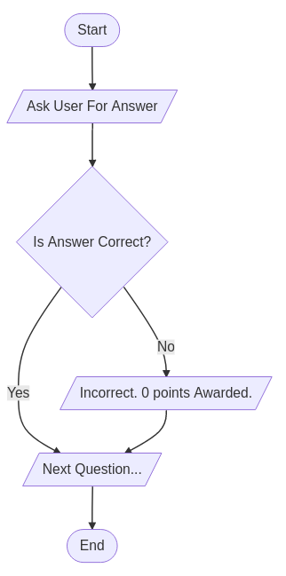

The different shapes have special meaning which should you should take into account. Here are a few:

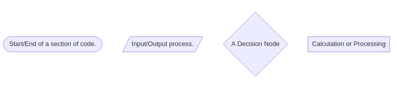

One advantage of flow charts over pseudocode is that it is far more obvious where looping and iteration will occur. Consider this example using a while loop:

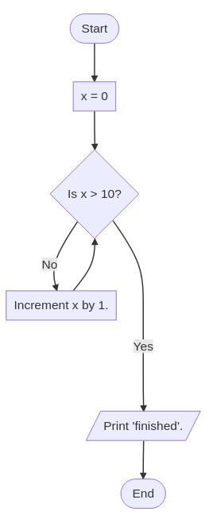

### TASK: Flow Chart to Code

- Use the flow chart above to guide you as you create the code it describes.
- There is one line missing: a print statement that prints the value of `x` inside the loop.
- Inside your script, add a print statement so that your output matches the sample output below.
- When you are finished, save this file as `lab3b.py` and include it in your lab submission.

#### Sample Output

```
0
1
2
3
4
5
6
7
8
9
10
finished
```

## 3.5 TASK: Using The Debugger

For this next section, open VSCode and enter the following:

```python
sum = 0
print("SUMMING CALCULATOR")
while True:
    print("The sum so far: " + str(sum))
    user_input = input("Enter a number to add to your sum. Pressing Enter will exit. ")
    if user_input == "":
        break
    else:
        sum += int(user_input)
print("Thank you for using summing calculator. The final sum was " + str(sum) + ".")
```

Using `while True` turns this into an infinite loop, which is usually something we want to avoid. It essentially tests if `True == True`, with no way of modifying this condition after each iteration. The only way to break out of the loop is to press Enter, which will set `user_input` to `""`.

Notice we have created a new variable `user_input` and moved the conversion to `int()` onto a different line, only after we have tested to see if the user has entered blank input (Enter key with no other characters) to skip. The reason is if we try to run `int('')`, we will cause an exception. For now, let’s try to avoid exceptions using if statements, later on we will show ways to handle exceptions directly.

You’ll also notice a new operator: `+=`. To demonstrate how this works, we are going to *step through* our code.

1. Save your file as `lab3c.py`.
2. From VSCode, click the ‘Run and Debug’ icon on the left. It looks like a play button with a bug next to it.

[figure not shown]

3. In the left panel, you will see a new ‘Run and Debug’ button as well as the option to customize launch options by opening a ‘launch.json’ file. Click this now.
4. `launch.json` will open in a new tab. A JSON file is just another way of storing configuration data, but it can be confusing at first glance. Click “Add Configuration” and select “Python” from the drop-down list. If you do not see Python as an option, make sure you have installed the Python extension.

[figure not shown]

   By creating a `launch.json` file, we can save our Python settings and won’t have to specify ‘Python’ each time we run the file. Press `Ctrl+s` to save `launch.json` with its default values. Your `launch.json` file should look similar to mine, and in the top-left corner you should have an option to run “Python: Current File”.

[figure not shown]

5. Now close `launch.json` and return to `lab3c.py`. You should see a play button appear in the left panel. Press that now. In the terminal that appears, you should be able to interact with your program normally.

The real power of the debugger occurs when we set *break points*. Break points will allow us to ‘pause’ the program at various stages, and examine the state of variables.

[figure not shown]

3. The arrow indicates that we are about to run the instructions on line 4. At the top, find the “Step Over” button. Press it now.
4. In the terminal, you should see that the line 4 print instruction has completed, and that in the **terminal below** you can see “`SUMMING CALCULATOR`” has been printed. Look in the top-left corner, for the panel that says “Variables”. You should see `sum` listed there, with its initial value of 0.
5. Press “Step over” two more times so that the terminal is now prompting you to enter a number. Enter “3” as your number and press Enter.
6. The program is once again paused, and will check to see if your input is blank or not. You should see in the “Variables” box that `user_input` equals ‘3’. Use “Step over” once again to advance so that the arrow has returned to the top of loop.
7. This time, enter 4 at the prompt. Continue using Step over to advance the code. `sum` should now equal 7, and you should once again be at the top of the loop for the third iteration. This time around, you can press Enter to stop the program.
8. Using the debugger in this manner is an invaluable tool when things don’t seem to be working. The other buttons at the top will resume the code without stopping, or will restart the program from the first line.
9. So what does `+=` do? As you saw, the initial value of `sum` is preserved, while the value of `user_input` is added. `sum += user_input` is just another way of writing `sum = sum + user_input`.

**Note:**

There are other special incremental operators for each major mathematical operation: `+=`, `-=`, `*=` and `/=`.

## 3.4 TASK: Guess A Number Game

We are going to *iterate* on a game where the user guesses a number between 1 and 10. By ‘iterate’, we mean that we will start by building a minimal program and gradually add features.

For this first iteration, we will *hard-code* a `secret` number of 7. The user will enter their guess, and the game will continue for as long as it takes for the user to guess the number.

```python
secret = 7
user_guess = 0
```

### Planning Your Code

You will start by creating a **Flow Chart** for your code. Use the example code in 3.1 to help you do this. There are many, many programs and apps that will help you create flow charts:

- Microsoft Word: [This tutorial](https://www.makeuseof.com/tag/create-stunning-flowcharts-microsoft-word/) might prove useful.
- Libreoffice Draw: [The Libreoffice Suite](https://www.libreoffice.org) is a good open source alternative to Microsoft Office.
- Draw.io: [The Webapp](https://app.diagrams.net/) is more than adequate for our needs.

I recommend Draw.io, it requires no installation and is fairly intuitive. Whatever you use, please export your flow chart as a **PDF File** named `flowchart.pdf`. Include it in your lab submission.

### Write The Program

Use what you’ve learned to create a while loop that checks if `user_guess` is equal to `secret`. It will be easier to build upon this game if we don’t put 7 directly in our while instruction. Eventually we are going to set a new number each time we run the game.

### Sample Output

```
Guess a number between 1 and 10: 3
Sorry, that's not it.
Guess a number between 1 and 10: 5
Sorry, that's not it.
Guess a number between 1 and 10: 7
Correct! You win.
```

- Name this script `lab3d.py` and include it with your lab submission.
- Remember to convert the value from `input` into an integer.
- You can use an if statement inside the while loop to print the “Sorry” message.
- Test your script and make sure your output matches the Sample Output before proceeding. If you get stuck, refer to section 3.1 for hints.

## 3.5 Importing Code

Python is an incredibly popular programming language for a couple of reasons: compared to a lot of other programming languages, it’s quick easy to read. But the other reason is because of its *Standard Library*. You see, Python comes with a lot of useful functions and tools included. Some functions (such as `print()` and `input()`) are so common that they are built into the language itself. A lot of other functions, however, are only useful in certain situations. Code like this are stored in *Modules* and so we can *import* them only when needed.

## 3.6 TASK: Guessing Random Numbers

One such module is `random`. This module contains a lot of functions that allow you to work with random numbers. You can make use of these functions by adding the following code to the top of your script:

```python
import random
```

If you only need one function, it’s usually better to specify that instead. Our guessing game is going to use a function to choose a random number inside a range of possible values. These numbers need to be whole numbers so that the game is fair.

1. Open `lab3d.py` if you don’t have it open already.
2. At the top, enter the line `from random import randint`
3. On the line where you specify `secret = 7`, replace 7 with the following: `randint(1, 10)`.
4. What does this code mean? `randint` will return an integer between a range. The highest possible value will be 10.
5. Every time you start the game, a new integer will be returned. Save `lab3d.py` and test the code using the debugger. Use what you’ve learned to verify that the `secret` variable changes each time you run.

There are many, *many* modules in the Python standard library, meaning that Python is a good language to accomplish all kinds of tasks. In the future when you tackle new challenges, remember to check and see if there is a module that you can use. **It’s always better to use an existing tool if possible**.

### Sample Output

```
Guess a number between 1 and 10: 3
Sorry, that's not it.
Please enter a valid number between 1 and 10.
Guess a number between 1 and 10: 7
Sorry, that's not it.
Guess a number between 1 and 10: 4
Correct! You win.
```

## 3.7 TASK: Math Quiz v2.0

- Make a *copy* of your `lab3a.py` file and name it `lab3e.py`.
- Replace the hard-coded numbers and answers with random integers using the `random` module.
- Instead of asking only four questions, allow the user to continue as long as they want, until they press `'q'` to quit.
- Once the user has quit, display the correct score as a percentage. **Note:** don’t count the question the pressed `'q'` on as a fail, only the questions they skipped.

### Sample Output

```
Enter the answer to 1 + 6, press 's' to skip or 'q' to quit: 27
Incorrect. Try again.
Enter the answer to 1 + 6, or press 's' to skip or 'q' to quit: 7
Correct! You have been awarded 1 point!"
Next question...
Enter the answer to 2 + 18, or press 's' to skip: s
Question skipped. 0 points awarded.
Enter the answer to 17 + 5, or press 's' to skip: q
Quiz over. You scored 50.0%.
```

## CHALLENGE TASK: Binary Converter

Binary numbers are used internally by all computers. Binary numbers are composed only of ones and zeroes. If you would like an introduction to binary systems, you can visit [Khan Academy](https://www.khanacademy.org/math/algebra-home/alg-intro-to-algebra/algebra-alternate-number-bases/v/number-systems-introduction) or refer to my [notes](https://ict.senecacollege.ca/~eric.brauer/uli101/lecture4a.html).

One way to convert a decimal number into binary is to use the following procedure (again, my [notes](https://ict.senecacollege.ca/~eric.brauer/uli101/lecture4a.html) cover this process in much more detail):

1. Start with a decimal number. Divide that number by 2.
2. The *remainder* of that division will be either 0 or 1. The remainder becomes the *least significant bit* of the binary number.
3. The *quotient* of that division will be used in the next step.
4. Divide the quotient by 2.
5. Again, the *remainder* becomes the *next least significant bit*. The quotient is again used for the next step.
6. Continue this process until the quotient is 1.
7. The 1 becomes the *most significant bit* of the binary number.

Use this process to complete `challenge3.py`.

- Use `input` to ask the user for a decimal number.
- Convert the number to binary using the process above, or *another similar process* if you prefer.
- You can use the `bin()` function to check your work.
- Use comments to explain your approach, especially if you use a different process from mine!

## Deliverables

- `lab3a.py`
- `lab3b.py`
- `lab3c.py`
- `lab3d.py`
- `lab3e.py`
- `flowchart.pdf`
- `challenge3.py`
- `lab3-check-output.txt`

## Glossary

- Iteration
- Increment
- Module
- Break Point
- Step Over